# Compulsory Exercise 2: Title (give your project an informative title)

## 0.4 Results and interpretation

#### 0.4.0.1 Logistic regression

After some testing we excluded **RestingECG**, **MaxHR**, **Age**, and **RestingBP** from the analysis due to non-significant p-values when included in a model with all dependent variables. We then fitted the model to the training set and used a $0.5$ classification cutoff to predict the test set, generating a confusion matrix to evaluate performance.

```r
logRegModel <- glm(HeartDisease ~ . - RestingECG - MaxHR - Age - RestingBP, data = train,
    family = "binomial")
logRegPrediction <- predict(logRegModel, test, type = "response")
logRegPredictionClassified <- ifelse(logRegPrediction > 0.5, 1, 0)
logRegConfusionMatrix <- confusionMatrix(data = as.factor(logRegPredictionClassified),
    reference = as.factor(test$HeartDisease), positive = "1")
```

We get a misclassification error of $0.1413$, sensitivity of $0.8899$ and specificity $0.8235$. As a rule of thumb the sum of specificity and sensitivity should be at least $1.5$, which means our model is performing quite well, though we might want to increase the sensitivity of the model. To get a better idea of what cutoff to chose we plot the ROC curve.

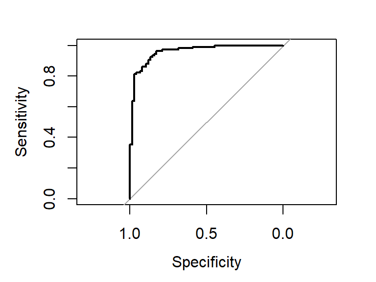

Figure 2: ROC curve – Logistic Regression

```r
logRegROC = roc(test$HeartDisease, logRegPrediction)
plot(logRegROC)
```

From the ROC curve we find that $0.5$ seems to work well as a cutoff, but we might be able to increase the sensitivity without drastically decreasing performance. Therefore we try a cutoff of $0.3$.

```r
logRegPredictionClassified <- ifelse(logRegPrediction > 0.3, 1, 0)
logRegConfusionMatrix <- confusionMatrix(data = as.factor(logRegPredictionClassified),
    reference = as.factor(test$HeartDisease), positive = "1")
```

We get misclassification error of $0.163$, a sensitivity of $0.939$ and specificity of $0.718$. Which we find to be a better result than the $0.5$ cutoff, due to the increase in sensitivity while slightly increasing the misclassification error. From the ROC curve we find that further increases in sensitivity will give diminishing returns while lowering the general performance.

```r
logRegModel$coefficients
```

```
##      (Intercept)             SexM ChestPainTypeATA ChestPainTypeNAP
##     -0.425892384      1.246703946     -1.752056598     -1.633373302
##  ChestPainTypeTA      Cholesterol       FastingBS1  ExerciseAnginaY
##     -1.186753974     -0.004164823      1.205445288      0.930457343
##          Oldpeak     ST_SlopeFlat       ST_SlopeUp
##      0.449708938      1.335198463     -1.072069692
```

From the coefficients we find that **ST_Slope** and **ChestPainType** have the largest impact on the odds of heart disease. In particular people with a flat slope or asymptomatic chest pains have higher chances of heart disease. Otherwise we find that **SexM, FastingBS, ExerciseAnginaY** and **Oldpeak** all increase the odds, while **Cholesterol** decreases them slightly.

#### 0.4.0.2 Random Forest

We create a random forest model using the $\texttt{randomForest()}$ function from the **randomForest** library:

```r
model <- randomForest(HeartDisease ~ ., data = train, importance = TRUE)
```

Perform prediction on unseen test data, and assess the prediction through a confusion matrix:

```r
prediction <- predict(model, test)
confusionMatrix <- confusionMatrix(data = prediction, reference = test$HeartDisease)
confusionMatrix$overall
```

```
##       Accuracy          Kappa  AccuracyLower  AccuracyUpper   AccuracyNull
##   8.858696e-01   7.659884e-01   8.308419e-01   9.279468e-01   5.869565e-01
## AccuracyPValue  McnemarPValue
##   4.389913e-19   6.625206e-01
```

First we investigate the number of trees in the forest. The number of trees is not a tuning parameter, it is just a question of whether we have enough trees for optimal classification, and of course we want as few trees as possible within this range to keep the complexity down. We plot the error rates for the positive, negative and Out-of-bag observations as functions of number of trees:

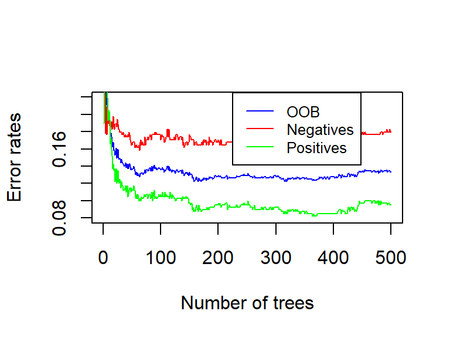

Figure 3: Error rates vs number of trees

```r
plot(model$err.rate[, 1], type = "l", ylim = c(0.08, 0.22), ylab = "Error rates",
    xlab = "Number of trees", col = "blue")
lines(model$err.rate[, 2], col = "red")
lines(model$err.rate[, 3], col = "green")
legend(225, 0.225, legend = c("OOB", "Negatives", "Positives"), col = c("blue", "red",
    "green"), lty = 1, cex = 0.8)
```

Furthermore, we investigate the number of variables considered in each split in the trees. The default value in the $\texttt{randomForest()}$ function for classification problems corresponds to the floored square root of the number of predictors, in our case 3. The number of predictors considered can be seen as a tuning parameter, since we on one hand want to decorrelate the trees by allowing only a subset of the predictors to be considered, while we on the other hand need enough predictors to split the data properly and avoid bias. To find the optimal value, we test all possible number of predictors, i.e. 1 through 11. In each iteration, we store the OOB error rate at the final iteration.

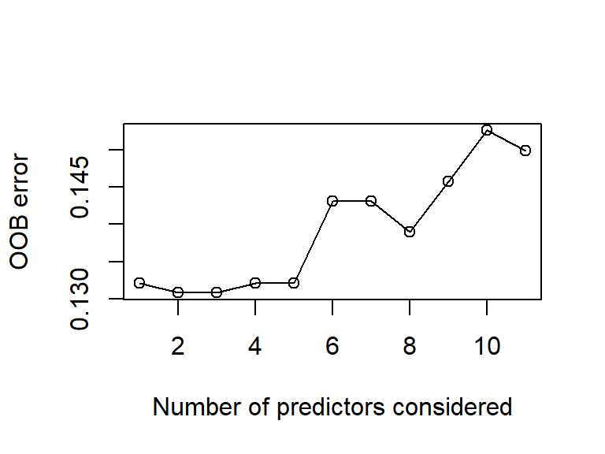

Figure 4: OOB error vs number of predictors

```r
oobValues = vector(length = 11)
for (i in 1:11) {
    newModel <- randomForest(HeartDisease ~ ., data = train, mtry = i, proximity = TRUE)
    oobValues[i] <- newModel$err.rate[nrow(newModel$err.rate), 1]
}
plot(oobValues, type = "o", xlab = "Number of predictors considered", ylab = "OOB error")
```

Observing the plot, the OOB error does vary depending on the number of predictors that are considered in each tree split. However, running the experiment multiple times shows that there is no unique optimal value, since the optimal value changes every iteration. It does seem like the model does not require many predictors to keep the OOB error down, which may be an indicator that the predictors are correlated and it is sufficient to only consider a few of them to split the data properly.

We create a new model with adjusted hyperparameters. We use $\texttt{ntree}=100$ and $\texttt{mtry}=2$.

```r
adjustedModel <- randomForest(HeartDisease ~ ., data = train, mtry = 2, ntree = 100,
    importance = TRUE)

adjustedPrediction <- predict(adjustedModel, test)

confusionMatrix2 <- confusionMatrix(data = adjustedPrediction, reference = test$HeartDisease)
confusionMatrix2$overall
```

```
##       Accuracy          Kappa  AccuracyLower  AccuracyUpper   AccuracyNull
##   9.021739e-01   7.990291e-01   8.498020e-01   9.409855e-01   5.869565e-01
## AccuracyPValue  McnemarPValue
##   2.163190e-21   8.136637e-01
```

```r
probabilityPrediction <- predict(adjustedModel, test, type = "prob")
ROC <- roc(test$HeartDisease, probabilityPrediction[, 2])
ROC$auc
```

```
## Area under the curve: 0.9521
```

The model yields an AUC score of more than 0.9, which is good in almost all cases.

In addition to creating a predictive model, we want the model to say something about the relation between the response and the different covariates, i.e. inference. We use the $\texttt{varImpPlot()}$ function from the **randomForest** library, which approximates how separate predictors affects the accuracy of the model and the impurity of the root nodes in the trees of the model (measured by the Gini index).

[figure not shown]

```r
varImpPlot(adjustedModel)
```

Examining the plots, it seems like the **ST_Slope** and **ChestPainType** variables is most important for creating a good model, indicating that they have a strong correlation with the response variable. This is in agreement with the other logistic regression model.

## 0.5 Summary